# PM566 Assignment 3

Echo Tang

2022-11-04

```r
library(stringr)
library(httr)
library(xml2)
library(rvest)
library(tidyverse)
library(data.table)
```

## APIs

```r
website <- xml2::read_html("https://pubmed.ncbi.nlm.nih.gov/?term=sars-cov-2+trial+vaccine")

counts <- xml2::xml_find_first(website, "/html/body/main/div[9]/div[2]/div[2]/div[1]/div[1]/span")

counts <- as.character(counts)

stringr::str_extract(counts, "([0-9]+[.,]*)+")
```

```
## [1] "4,009"
```

As of Nov. 4, there are 4009 results for “sars-cov-2 trial vaccine.”

### Getting query IDs and downloading details

```r
query_ids <- GET(
  url   = "https://eutils.ncbi.nlm.nih.gov/entrez/eutils/esearch.fcgi",
  query = list(
    db      = "pubmed",
    term    = "sars-cov-2 trial vaccine",
    retmax  = 250
  ),
)

ids <- httr::content(query_ids)
ids <- as.character(ids)
ids <- stringr::str_extract_all(ids, "<Id>[[:digit:]]+</Id>")[[1]]
ids <- stringr::str_remove_all(ids, "</?Id>")

publications <- GET(
  url   = "https://eutils.ncbi.nlm.nih.gov/entrez/eutils/efetch.fcgi",
  query = list(
    db = "pubmed",
    id = paste(ids, collapse = ","),
    retmax = 250,
    rettype = "abstract"
    )
)

publications <- httr::content(publications)

pub_char_list <- xml2::xml_children(publications)
pub_char_list <- sapply(pub_char_list, as.character)
```

### Form a database from publication details

```r
abstracts <- str_extract(pub_char_list, "<Abstract>[[:print:][:space:]]+</Abstract>")
abstracts <- str_remove_all(abstracts, "</?[[:alnum:]- =\"]+>")
abstracts <- str_replace_all(abstracts, "[[:space:]]+"," ")

titles <- str_extract(pub_char_list, "<ArticleTitle>.*</ArticleTitle>")
titles <- str_replace_all(titles, "</?[[:alpha:]]+>", "")

journals <- str_extract(pub_char_list, "<Title>.*</Title>")
journals = str_remove_all(journals, "</?[:alpha:]+>")

dates <- str_remove_all(pub_char_list, "\\n") %>% str_extract("<PubDate>.*</PubDate>") %>% str_squish()
dates = str_remove_all(dates, "</?[:alpha:]+>") %>% str_trim(side = "both")

database <- data.frame(
  PubMedId = ids,
  Title    = titles,
  Abstract = abstracts,
  Journal = journals,
  PubDate = dates
)

knitr::kable(database[1:5,], caption = "Database of SARS-COV-2 Trial Vaccine Papers")
```

Database of SARS-COV-2 Trial Vaccine Papers

| PubMedId | Title | Abstract | Journal | PubDate |
| --- | --- | --- | --- | --- |
| 36328399 | Immunogenicity and safety of a three-dose SARS-CoV-2 vaccination strategy in patients with immune-mediated inflammatory diseases on immunosuppressive therapy. | Humoral vaccine responses to SARS-CoV-2 vaccines are impaired and short lasting in patients with immune-mediated inflammatory diseases (IMID) following two vaccine doses. To protect these vulnerable p… | RMD open | 2022 Nov |
| 36327352 | S-217622, a SARS-CoV-2 main protease inhibitor, decreases viral load and ameliorates COVID-19 severity in hamsters. | In parallel with vaccination, oral antiviral agents are highly anticipated to act as countermeasures for the treatment of the coronavirus disease 2019 (COVID-19) pandemic caused by severe acute respir… | Science translational medicine | 2022 Nov 03 |
| 36322837 | Covid-19 Vaccine Protection among Children and Adolescents in Qatar. | The BNT162b2 vaccine against coronavirus disease 2019 (Covid-19) has been authorized for use in children 5 to 11 years of age and adolescents 12 to 17 years of age but in different antigen doses. We a… | The New England journal of medicine | 2022 Nov 02 |
| 36320825 | Withholding methotrexate after vaccination with ChAdOx1 nCov19 in patients with rheumatoid or psoriatic arthritis in India (MIVAC I and II): results of two, parallel, assessor-masked, randomised contr… | There is a necessity for an optimal COVID-19 vaccination strategy for vulnerable population groups, including people with autoimmune inflammatory arthritis on immunosuppressants such as methotrexate, … | The Lancet. Rheumatology | 2022 Nov |
| 36314847 | An online community peer support intervention to promote COVID-19 vaccine information among essential workers: a randomized trial. | Vaccine hesitancy is still rampant in the United States, including health care personnel. Vaccination of frontline essential workers (e.g. health care workers) is very important, especially during a p… | Annals of medicine | 2022 Dec |

## Text Mining

```r
if (!file.exists("pubmed.csv"))
  download.file(
    url = "https://raw.githubusercontent.com/USCbiostats/data-science-data/master/03_pubmed/pubmed.csv",
    destfile = "pubmed.csv",
    method   = "libcurl",
    timeout  = 60
    )
pubmed = fread("pubmed.csv")
pubmed %>% count(term) %>% arrange(desc(n)) %>% knitr::kable()
```

| term | n |
| --- | --- |
| covid | 981 |
| prostate cancer | 787 |
| preeclampsia | 780 |
| cystic fibrosis | 376 |
| meningitis | 317 |

The most abstracts are about COVID, with 981 abstracts falling under this term. The next most common terms were prostate cancer and preeclampsia at 787 and 780 abstracts respectively, followed by cystic fibrosis and meningitis.

### Tokenize the abstracts

```r
library(tidytext)

pubmed %>% unnest_tokens(token, abstract) %>% count(token, sort=T) %>% top_n(20) %>% knitr::kable()
```

| token | n |
| --- | --- |
| the | 28126 |
| of | 24760 |
| and | 19993 |
| in | 14653 |
| to | 10920 |
| a | 8245 |
| with | 8038 |
| covid | 7275 |
| 19 | 7080 |
| is | 5649 |
| for | 5492 |
| patients | 4674 |
| cancer | 3999 |
| prostate | 3832 |
| was | 3315 |
| that | 3226 |
| were | 3226 |
| as | 3159 |
| this | 3158 |
| are | 2833 |

Most of the top 20 most common words are stop words, except for “covid,” “19,” “patients,” “cancer,” and “prostate.” COVID and prostate cancer are the two most popular terms for the abstracts, which makes sense why they appear very commonly. Patients also appears a lot, which also makes sense considering all the terms that the abstracts fall under are medical conditions.

```r
all_token = pubmed %>% unnest_tokens(token, abstract) %>% count(token, sort=T)
all_token %>% anti_join(stop_words, by = c("token" = "word")) %>% filter(!grepl(pattern = "^[0-9]+$", x = token)) %>% top_n(5) %>% knitr::kable()
```

| token | n |
| --- | --- |
| covid | 7275 |
| patients | 4674 |
| cancer | 3999 |
| prostate | 3832 |
| disease | 2574 |

### Tokenizing into bigrams

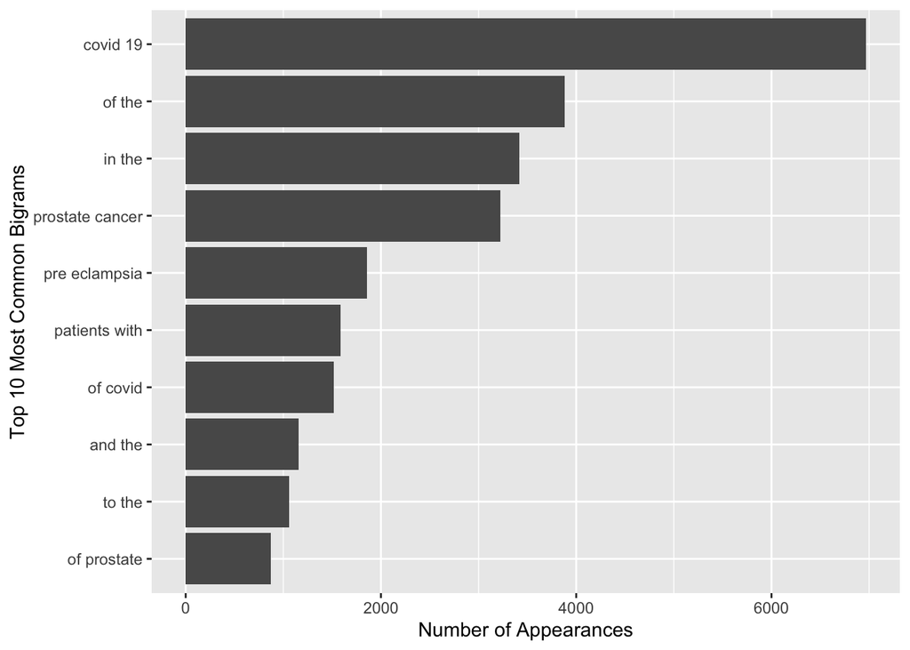

```r
bigrams = pubmed %>% unnest_ngrams(ngram, abstract, n = 2) %>% count(ngram, sort=T)
bigrams %>% top_n(10) %>% ggplot(aes(x = n, y = fct_reorder(ngram, n))) + geom_col() + ylab("Top 10 Most Common Bigrams") + xlab("Number of Appearances")
```

The most frequently appearing bigram was “covid 19” with almost seven thousand appearances, which again makes sense given that COVID 19 makes up the most abstracts in this dataset. Interestingly, this was far more frequent than the next to most popular bigrams “of the” and “in the,” which consist only of stop words. The next most common bigrams after those three are “prostate cancer” and “pre eclampsia,” which similarly to COVID 19, are search terms. Other common bigrams include “patients with,” “of covid,” and “of prostate,” which incorporates search terms with stop words.

### Calculating TF-IDF

```r
pubmed_tokens = pubmed %>% unnest_tokens(token, abstract) %>% count(term, token, sort = TRUE)

pubmed_tokens %>% bind_tf_idf(token, term, n) %>% arrange(desc(tf_idf)) %>% top_n(5) %>% select(term, token, n, tf_idf) %>% knitr::kable()
```

| term | token | n | tf_idf |
| --- | --- | --- | --- |
| covid | covid | 7275 | 0.0597183 |
| prostate cancer | prostate | 3832 | 0.0501967 |
| preeclampsia | eclampsia | 2005 | 0.0229802 |
| preeclampsia | preeclampsia | 1863 | 0.0213527 |
| meningitis | meningitis | 429 | 0.0147974 |

The top 5 TF-IDF words were “covid,” “prostate,” “eclampsia,” “preeclampsia,” and “meningitis.”

“covid” and “prostate” were shared with what was gotten in number 1, but “cancer” and “disease” are not in the top 5 TF-IDF terms. Instead, “eclampsia,” “preeclampsia,” and “meningitis” are in the top 5 TF-IDF tokens; this also makes sense because preeclampsia and meningitis are two of the five terms that the abstracts fall under. Interestingly, neither “cystic” nor “fibrosis” appear in the top 5 TF-IDF words even though it is one of the five terms.